# NAEP 2018 Oral Reading Fluency Analysis

Emma Shanahan

2025-08-09

# Introduction

In this R Markdown file, I used a publicly available education dataset, the [2018 National Assessment of Educational Progress grade 4 oral reading fluency (ORF) public use data file](https://nces.ed.gov/nationsreportcard/studies/orf/data_product.aspx). This dataset includes data from 1,800 public school fourth grade students who participated in the 2018 ORF study.

In this report, I investigated the following research question:

To what extent does pseudoword reading fluency moderate the association between emergent bilingual status and oral reading fluency?

I hypothesize that the association between pseudoword reading and ORF will be stronger for emergent bilingual learners than their peers with English proficiency, because knowledge of phoneme-grapheme correspondences within words is likely more relevant for fourth graders who are still acquiring phonological knowledge in English.

In the following sections, I (1) identify variables of interest, (2) clean the data, (3) calculated descriptive statistics, and (4) conduct the moderator analysis using linear regression to answer my research question.

# 1. Identify variables of interest

NAEP uses a complex survey design with full-sample and replicate weights that adjust for unequal probabilities of selection. For the purposes of this exercise, NAEP-provided sampling weights were not applied in the analyses. As a result, the estimates should be interpreted as unweighted and may not be nationally representative; standard errors may also be underestimated because the complex sampling design was not accounted for.

I used the publicly available codebook to identify variables of interest.

```r
###########################################################
##### IDENTIFY VARIABLES
###########################################################

# Select variables of interest
df1 <- df %>%
  select(CASEID,     # Student ID
         LEP,        # Limited English proficiency status
         WLISTCPM,   # Word reading correct words per minute
         PLISTCPM,   # Pseudoword reading correct words per minute
         PWCPM       # Passage reading words correct per minute
         )
```

# 2. Clean the data

I assigned variable labels and value labels. I also binary coded LEP (limited English proficiency, the emergent bilingual variable) for the regression.

```r
###########################################################
##### CLEAN THE DATA - VARIABLES
###########################################################

# Create variable labels
var_labels <- c(
  CASEID = "Student ID",
  LEP = "Emergent Bilingual Status",
  WLISTCPM = "Words Correct Per Min",
  PLISTCPM = "Pseudowords Correct Per Min",
  PWCPM = "Passage Words Correct Per Min")
df1 <- set_label(df1, label = var_labels)

# Binary code LEP
df1 <- df1 %>%
  mutate(LEP = case_when(LEP == 1 ~ 1,
                         LEP == 2 ~ 0))

# Create LEP value label - Yes, No
value_labels <- list(
  LEP = c("Yes" = 1, "No" = 0))
for (v in names(value_labels)) {
  if (v %in% names(df1)) {
    df1[[v]] <- set_labels(df1[[v]], labels = value_labels[[v]])}}
```

Next, I checked for the missing data value or values, which weren’t defined in the codebook. An NA count came up 0, so I checked variable values for common missing data codes. Since these variables are numeric, I assumed that plausible missing data codes are negative (these literacy scores would be positive) or over 300 (a score of 300 correct words per minute is unlikely). No likely missing data values were identified, so we can infer that this dataset does not have missing data. The public-use file codes these as true numeric values.

```r
###########################################################
##### CLEAN THE DATA - MISSINGNESS
###########################################################

# Check for NAs
colSums(is.na(df1))
```

```
##   CASEID      LEP WLISTCPM PLISTCPM    PWCPM
##        0        0        0        0        0
```

```r
# Check for unidentified NA values
num_vars <- sapply(df1, is.numeric)
suspect_codes <- c(-99, -9, -8, -7, 777, 888, 999, 8888, 9999)
missing_summary <- sapply(df1[, num_vars], function(x) {
  sum(x %in% suspect_codes, na.rm = TRUE)})
missing_summary[missing_summary > 0]
```

```
## named integer(0)
```

# 3. Calculate descriptive statistics

Next, I looked at the distributions of variables of interest. None are outside acceptable ranges of skew (|2|) or kurtosis (|4|).

```r
###########################################################
##### DISTRIBUTIONS
###########################################################

# Calculate M, SD, skew, kurtosis
df_n <- df1 %>%
  select(WLISTCPM, PLISTCPM, PWCPM) %>%
  rename(`Words Correct Per Min` = WLISTCPM,
         `Pseudowords Correct Per Min` = PLISTCPM,
         `Passage Words Correct Per Min` = PWCPM)
numeric_vars <- df_n %>%
  select(where(is.numeric)) %>%
  names()
describe(df_n)
```

|  | vars | n | mean | sd | median | trimmed | mad | min | max | range | skew | kurtosis | se |
| --- | --- | --- | --- | --- | --- | --- | --- | --- | --- | --- | --- | --- | --- |
| Words Correct Per Min | 1 | 1800 | 50.10261 | 15.03893 | 53.3 | 52.03104 | 12.89862 | 0 | 71.800 | 71.800 | -1.18429342 | 1.2630767 | 0.3544710 |
| Pseudowords Correct Per Min | 2 | 1800 | 21.32994 | 10.98879 | 21.2 | 21.22035 | 12.15732 | 0 | 49.600 | 49.600 | 0.08546671 | -0.7284832 | 0.2590084 |
| Passage Words Correct Per Min | 3 | 1800 | 116.31737 | 35.34046 | 117.4 | 117.04187 | 36.67582 | 14 | 217.675 | 203.675 | -0.15554508 | -0.3280073 | 0.8329826 |

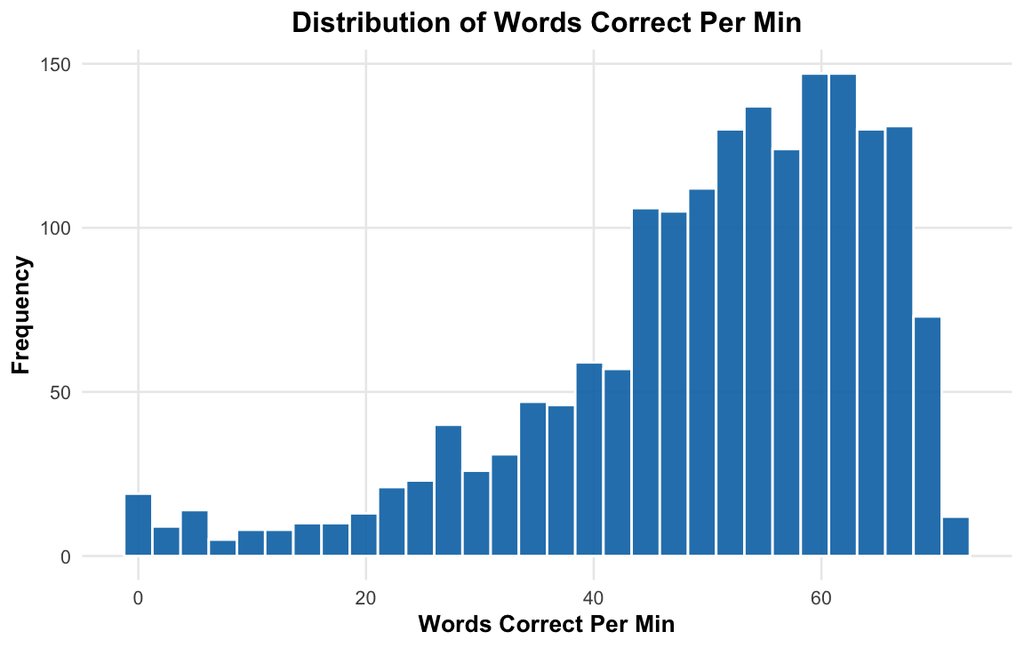

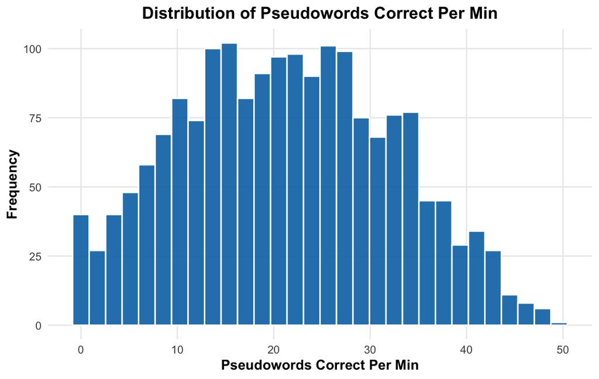

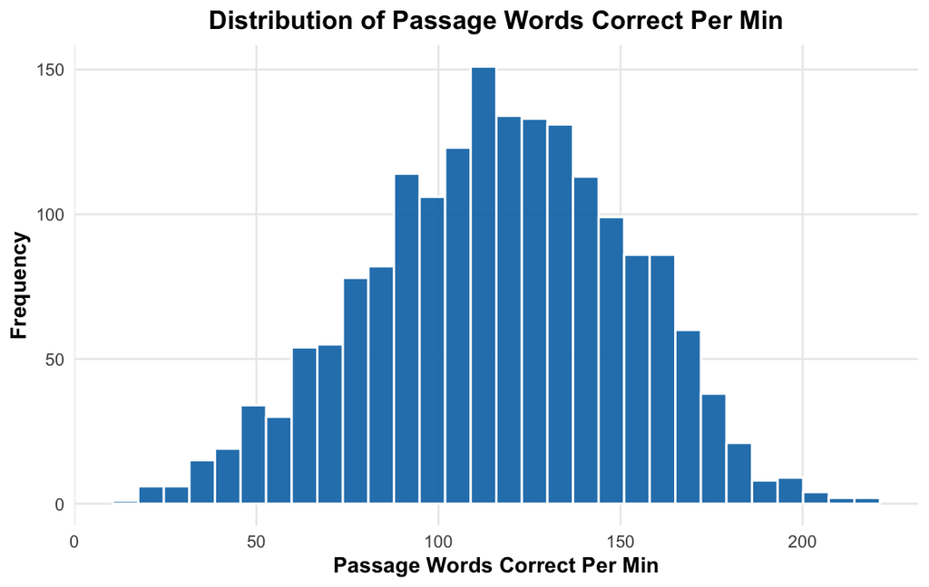

```r
# Histograms
plot_histogram <- function(data, var, bins = 30) {
  rng <- range(data[[var]], na.rm = TRUE)
  bw  <- diff(rng) / bins
  ggplot(data, aes(x = .data[[var]])) +
    geom_histogram(fill = "#0072B2", color = "white", alpha = 0.9) +
    theme_minimal(base_size = 10) +
    labs(
      title = paste("Distribution of", var),
      x     = var,
      y     = "Frequency") +
    theme(
      plot.title      = element_text(hjust = 0.5, face = "bold"),
      axis.title      = element_text(face = "bold"),
      panel.grid.minor = element_blank())}
hist_list <- map(numeric_vars, ~plot_histogram(df_n, .x))
hist_list
```

I looked at correlations between analysis variables. Unsurprisingly, correlations between word reading and passage words correct per minute (i.e., ORF) are high. Emergent bilingual status has weak negative correlations with the three reading skills.

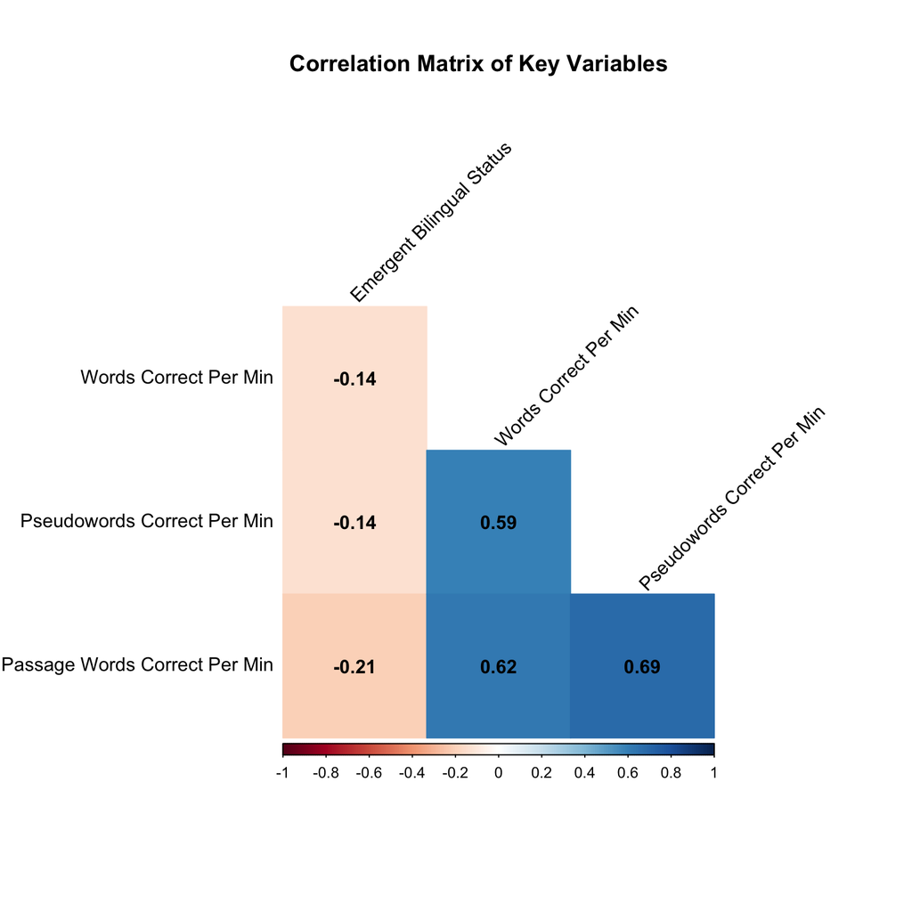

```r
###########################################################
##### CORRELATIONS
###########################################################

# Compute correlation matrix (pairwise complete obs)
df_c <- df1 %>%
  select(LEP, WLISTCPM, PLISTCPM, PWCPM) %>%
  rename(`Emergent Bilingual Status` = LEP,
         `Words Correct Per Min` = WLISTCPM,
         `Pseudowords Correct Per Min` = PLISTCPM,
         `Passage Words Correct Per Min` = PWCPM)
cor_mat <- cor(df_c, use = "pairwise.complete.obs")

# Visualize
corrplot(
  cor_mat,
  method       = "color",          # colored squares
  type         = "lower",          # lower triangle only
  order        = "hclust",         # order vars by similarity
  addCoef.col  = "black",          # show correlation values
  tl.col       = "black",          # variable label color
  tl.srt       = 45,               # rotate labels
  diag         = FALSE)
title("Correlation Matrix of Key Variables", line = 1)
```

Below, I visualized the distribution of the outcome variable, ORF, by emergent bilingual status. On average, emergent bilingual learners read 20.86 fewer passage words correct per minute. In the next section, I investigate pseudoword reading as a moderator of this difference.

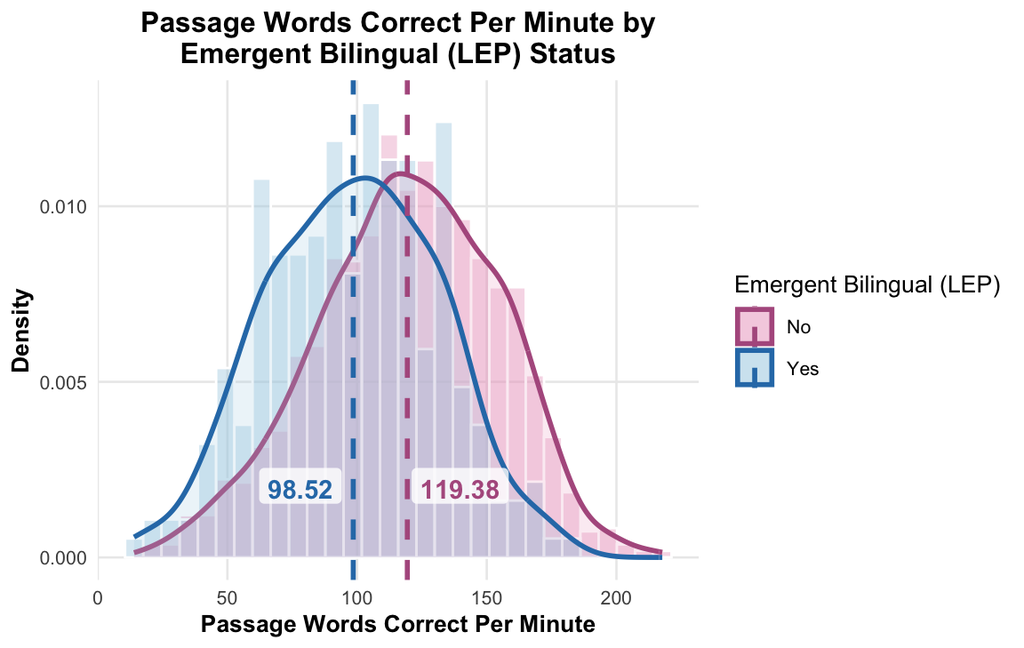

```r
###########################################################
##### ORF by LEP
###########################################################

# Prep for visualization
df1 <- df1 %>%
  mutate(LEP_fac = as.factor(LEP)) %>%
  mutate(LEP_fac = case_when(LEP_fac == 1 ~ "Yes",
                             LEP_fac == 0 ~ "No"))

# Calculate range-based nudge
nudge_amt <- diff(range(df1$PWCPM, na.rm = TRUE)) * -0.1

# Summarize group means & assign nudge
mean_df <- df1 %>%
  filter(!is.na(LEP_fac)) %>%
  group_by(LEP_fac) %>%
  summarize(mean_PWCPM = mean(PWCPM, na.rm = TRUE), .groups = "drop") %>%
  mutate(
    nudge = ifelse(LEP_fac == unique(LEP_fac)[1], -nudge_amt, nudge_amt)
  )

ggplot(df1, aes(x = PWCPM, fill = LEP_fac, color = LEP_fac)) +
  # Histogram
  geom_histogram(
    aes(y = after_stat(density)),
    position = "identity",
    alpha    = 0.4,
    bins     = 30,
    color    = "white") +
  # Density curves
  geom_density(alpha = 0.2, size = 1) +
  # Vertical mean lines
  geom_vline(
    data = mean_df,
    aes(xintercept = mean_PWCPM, color = LEP_fac),
    linetype = "dashed",
    linewidth = 1) +
  # Mean labels with white background, smaller font, and nudged horizontally
  geom_label(
    data = mean_df,
    aes(
      x     = mean_PWCPM + nudge,  # nudge horizontally
      y     = 0,
      label = round(mean_PWCPM, 2),
      color = LEP_fac),
    fill       = "white",
    alpha      = 0.8,
    label.size = 0,
    vjust      = -1.5,
    fontface   = "bold",
    show.legend = FALSE) +
  scale_fill_manual(values = c("Yes" = "#A6CEE3", "No" = "#EBA6C6")) +
  scale_color_manual(values = c("Yes" = "#2C7BB6", "No" = "#B25C8E")) +
  theme_minimal(base_size = 10) +
  labs(
    title = wrap_title("Passage Words Correct Per Minute by Emergent Bilingual (LEP) Status"),
    x     = "Passage Words Correct Per Minute",
    y     = "Density",
    fill  = "Emergent Bilingual (LEP)",
    color = "Emergent Bilingual (LEP)") +
  theme(
    plot.title       = element_text(hjust = 0.5, face = "bold"),
    axis.title       = element_text(face = "bold"),
    panel.grid.minor = element_blank())
```

# 4. Conduct the moderator analysis

The purpose of my research question is to examine whether pseudoword reading is more strongly associated with ORF among emergent bilingual students than their English proficient peers.

The interaction between emergent bilingual status (LEP) and pseudoword reading (PLISTCPM) was negative (*b* = –0.15), indicating that the association between pseudoword reading and the outcome was slightly weaker for emergent bilingual students than for their peers. However, this difference was not statistically significant (*p* = 0.341), suggesting that the relationship between pseudoword reading and the outcome did not vary meaningfully by EL status.

```r
###########################################################
##### MODERATOR ANALYSIS
###########################################################

# Center predictor
df1 <- df1 %>%
  mutate(PLISTCPM_c = PLISTCPM - mean(PLISTCPM, na.rm = TRUE))

# Fit model
lm1 <- lm(PWCPM ~ 1 + LEP*PLISTCPM_c, data = df1)
summary(lm1)
```

```
##
## Call:
## lm(formula = PWCPM ~ 1 + LEP * PLISTCPM_c, data = df1)
##
## Residuals:
##    Min     1Q Median     3Q    Max
## -89.91 -17.07  -0.37  16.92  85.40
##
## Coefficients:
##                 Estimate Std. Error t value Pr(>|t|)
## (Intercept)    117.98548    0.64643 182.518  < 2e-16 ***
## LEP            -11.94254    1.77507  -6.728 2.31e-11 ***
## PLISTCPM_c       2.18651    0.05885  37.156  < 2e-16 ***
## LEP:PLISTCPM_c  -0.15380    0.16153  -0.952    0.341
## ---
## Signif. codes:  0 '***' 0.001 '**' 0.01 '*' 0.05 '.' 0.1 ' ' 1
##
## Residual standard error: 25.29 on 1796 degrees of freedom
## Multiple R-squared:  0.4887, Adjusted R-squared:  0.4878
## F-statistic: 572.1 on 3 and 1796 DF,  p-value: < 2.2e-16
```

As illustrated in the graph below, the peudoword reading-ORF slopes are not meaningfully different between emergent bilingual (LEP) and non-emergent bilingual students.

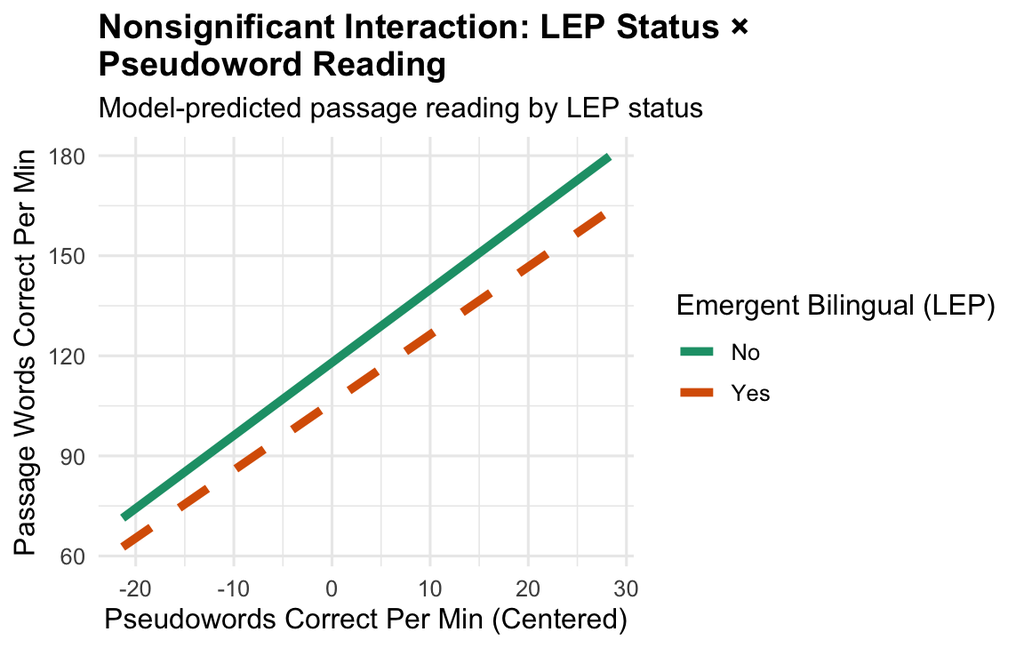

```r
###########################################################
##### MODERATOR ANALYSIS GRAPH
###########################################################

# Refit model for plot
df1$LEP_fac <- factor(df1$LEP, levels = c(0,1), labels = c("No","Yes"))
model <- lm(PWCPM ~ LEP_fac * PLISTCPM_c, data = df1)
newdat <- expand.grid(
  PLISTCPM = seq(min(df1$PLISTCPM_c, na.rm=TRUE),
                 max(df1$PLISTCPM_c, na.rm=TRUE), length.out = 100),
  LEP_fac = levels(df1$LEP_fac))
newdat <- expand.grid(
  PLISTCPM_c = seq(min(df1$PLISTCPM_c, na.rm = TRUE),
                   max(df1$PLISTCPM_c, na.rm = TRUE), length.out = 200),
  LEP_fac = levels(df1$LEP_fac))
newdat$PWCPM <- predict(model, newdata = newdat)

# Plot
ggplot(newdat, aes(PLISTCPM_c, PWCPM, color = LEP_fac, linetype = LEP_fac)) +
  geom_line(size = 1.7) +
  scale_color_manual(values = c("No" = "#1B9E77",  # teal-green
                                "Yes" = "#D95F02")) + # orange
  scale_linetype_manual(values = c("No" = "solid", "Yes" = "dashed")) +
  labs(
    title = wrap_title("Nonsignificant Interaction: LEP Status × Pseudoword Reading"),
    subtitle = "Model-predicted passage reading by LEP status",
    x = "Pseudowords Correct Per Min (Centered)",
    y = "Passage Words Correct Per Min",
    color = "Emergent Bilingual (LEP)",
    linetype = "Emergent Bilingual (LEP)") +
  theme_minimal(base_size = 12) +
  theme(
    plot.title = element_text(face = "bold"),
    legend.position = "right")
```

An appropriate next step is to fit a simpler model. The model that fits the data best, based on AICcs, is one that includes emergent bilingual status and pseudoword reading fluency as predictors. Meaning, both characteristics contribute to ORF. However, only 48.9% of the variance in the data is accounted for by this model, suggesting that other unknown factors are predicting ORF.

```r
###########################################################
##### SIMPLER MODELS
###########################################################

lm2 <- lm(PWCPM ~ LEP + PLISTCPM, data = df1)
lm3 <- lm(PWCPM ~ PLISTCPM, data = df1)

model.sel(lm1, lm2, lm3)
```

|  | (Intercept) | LEP | PLISTCPM_c | LEP:PLISTCPM_c | PLISTCPM | df | logLik | AICc | delta | weight |
| --- | --- | --- | --- | --- | --- | --- | --- | --- | --- | --- |
| lm2 | 71.79577 | -11.46192 | NA | NA | 2.166095 | 4 | -8367.447 | 16742.92 | 0.000000 | 6.344645e-01 |
| lm1 | 117.98548 | -11.94254 | 2.186506 | -0.1538006 | NA | 5 | -8366.993 | 16744.02 | 1.102836 | 3.655355e-01 |
| lm3 | 69.01526 | NA | NA | NA | 2.217639 | 3 | -8389.886 | 16785.79 | 42.868437 | 3.116337e-10 |

```r
summary(lm2)
```

```
##
## Call:
## lm(formula = PWCPM ~ LEP + PLISTCPM, data = df1)
##
## Residuals:
##     Min      1Q  Median      3Q     Max
## -89.805 -16.818  -0.447  17.070  85.392
##
## Coefficients:
##             Estimate Std. Error t value Pr(>|t|)
## (Intercept)  71.7958     1.3658  52.566  < 2e-16 ***
## LEP         -11.4619     1.7017  -6.735 2.19e-11 ***
## PLISTCPM      2.1661     0.0548  39.526  < 2e-16 ***
## ---
## Signif. codes:  0 '***' 0.001 '**' 0.01 '*' 0.05 '.' 0.1 ' ' 1
##
## Residual standard error: 25.29 on 1797 degrees of freedom
## Multiple R-squared:  0.4884, Adjusted R-squared:  0.4878
## F-statistic: 857.8 on 2 and 1797 DF,  p-value: < 2.2e-16
```

# Conclusion